# European Union COVID-19 Report

Muntadhar AlZayer

## EU COVID-19 report

I decided to work on the COVID-19 data for specific countries that have data with the European Center for Disease Control on their responses. I will clean the data, analyze it in relation to the stay at home orders, and model it to find correlation.

## Read in data

I used data provided by our professor during the course, and I inputted a dataset that gave the precaution responses during the pandemic by a few countries within the EU.

```r
url_in <- "https://raw.githubusercontent.com/CSSEGISandData/COVID-19/master/csse_covid_19_data/csse_covid_19_time_series/"
global_conf <- read_csv(str_c(url_in, "time_series_covid19_confirmed_global.csv"))
global_deaths <- read_csv(str_c(url_in,"time_series_covid19_deaths_global.csv"))
global_recovered <- read_csv(str_c(url_in, "time_series_covid19_recovered_global.csv"))

eu_url <- "https://www.ecdc.europa.eu/sites/default/files/documents/response_graphs_data_2021-05-26.csv"
eu_resp <- read_csv(eu_url)

uid_lookup_url <- "https://raw.githubusercontent.com/CSSEGISandData/COVID-19/master/csse_covid_19_data/UID_ISO_FIPS_LookUp_Table.csv"
uid <- read_csv(uid_lookup_url)
```

```r
global_conf <- global_conf %>% pivot_longer(cols=-c(`Province/State`, `Country/Region`, Lat, Long), names_to = "date", values_to = "cases") %>% select(-c(Lat, Long))

global_deaths <- global_deaths %>% pivot_longer(cols=-c(`Province/State`, `Country/Region`, Lat, Long), names_to = "date", values_to = "deaths") %>% select(-c(Lat, Long))

global <- global_conf %>% full_join(global_deaths) %>% rename(Country_Region = `Country/Region`, Province_State = `Province/State`) %>% mutate(date = mdy(date))
global <- global %>% filter(cases > 0)

global_recovered <- global_recovered %>% pivot_longer(cols=-c(`Province/State`, `Country/Region`, Lat, Long), names_to = "date", values_to = "recovered") %>% select(-c(Lat, Long))
global_recovered <- global_recovered %>% rename(Country_Region = `Country/Region`,Province_State = `Province/State`) %>% mutate(date = mdy(date))
global <- global %>% full_join(global_recovered)
global <- global %>% filter(cases > 0)
global
```

```
## # A tibble: 123,156 x 6
##    Province_State Country_Region date       cases deaths recovered
##    <chr>          <chr>          <date>     <dbl>  <dbl>     <dbl>
##  1 <NA>           Afghanistan    2020-02-24     1      0         0
##  2 <NA>           Afghanistan    2020-02-25     1      0         0
##  3 <NA>           Afghanistan    2020-02-26     1      0         0
##  4 <NA>           Afghanistan    2020-02-27     1      0         0
##  5 <NA>           Afghanistan    2020-02-28     1      0         0
##  6 <NA>           Afghanistan    2020-02-29     1      0         0
##  7 <NA>           Afghanistan    2020-03-01     1      0         0
##  8 <NA>           Afghanistan    2020-03-02     1      0         0
##  9 <NA>           Afghanistan    2020-03-03     2      0         0
## 10 <NA>           Afghanistan    2020-03-04     4      0         0
## # ... with 123,146 more rows
```

## Global data tidying

Here I tidy up the data and use the UID to extract the population of each country. There is no continous data on population amount, just a maximum.

```r
global <- global %>% unite("Combined_Key", c("Province_State", "Country_Region"), sep = ", ", na.rm = TRUE, remove = FALSE)


global <- global %>%
  left_join(uid, by=c("Province_State", "Country_Region", "Combined_Key")) %>%
  select(-c(UID,FIPS))
```

## EU Tidying data and joining

I wanted to have only the countries that have data on their stay at home orders, so I chose only that response from the EU dataset. I then joined the global dataset

```r
eu <- eu_resp %>% filter(Response_measure=="StayHomeOrder")
```

I then removed all the NA values from the end of the precaution dates, and set them to todays date. I also took all the rows that correspond to countries within the precautions dataset from the global continous data provided from John Hopkins database.

```r
eu[is.na(eu$date_end), "date_end"] = as.Date(today())
                                                          #%>% merge(x=global, y=eu_resp, by.x="Country_Region", by.y="Country")
eu_covid <- global[global$Country_Region %in% eu$Country,]

eu_covid <- eu_covid %>% select(-c(iso2, iso3, code3, Admin2))
```

### All of Europe

I first started by analyzing and visualizing the data for all the countries. This is a graph with the cumulative of: cases, deaths and recoveries.

```r
EU_cntries_ttl <- eu_covid %>% group_by(date) %>% summarize(recovered = sum(recovered), cases=sum(cases), deaths=sum(deaths), Population=sum(Population)) %>% select(date, cases, deaths, recovered, Population) %>% ungroup()
EU_cntries_ttl
```

```
## # A tibble: 496 x 5
##    date       cases deaths recovered Population
##    <date>     <dbl>  <dbl>     <dbl>      <dbl>
##  1 2020-01-24     2      0         0   65273512
##  2 2020-01-25     3      0         0   65273512
##  3 2020-01-26     3      0         0   65273512
##  4 2020-01-27     3      0         0   65273512
##  5 2020-01-28     4      0         0   65273512
##  6 2020-01-29     5      0         0   65273512
##  7 2020-01-30     5      0         0   65273512
##  8 2020-01-31     9      0         0  193621344
##  9 2020-02-01    11      0         0  240376127
## 10 2020-02-02    11      0         0  240376127
## # ... with 486 more rows
```

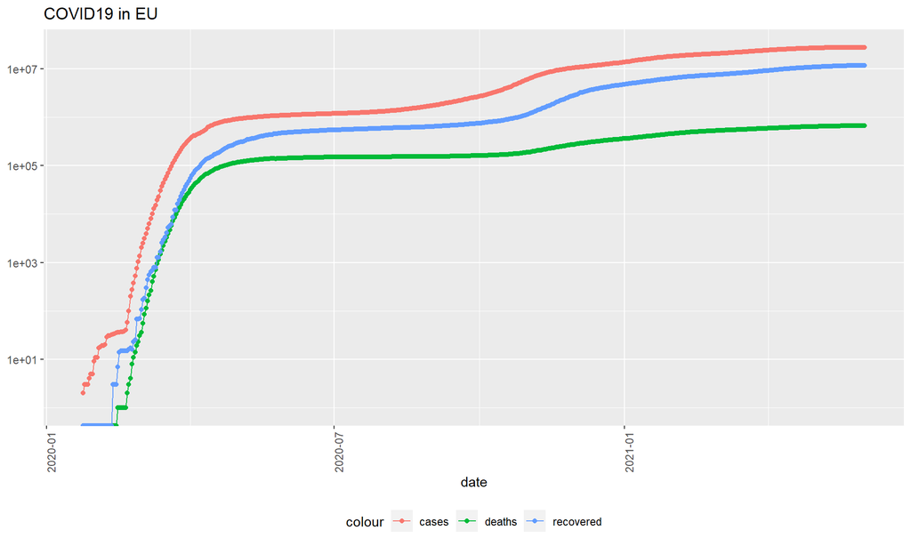

```r
EU_cntries_ttl %>% filter(cases>0) %>%
  ggplot(aes(x=date, y=cases)) +
  geom_line(aes(color="cases"))+
  geom_point(aes(color="cases"))+
  geom_line(aes(y=deaths, color="deaths"))+
  geom_point(aes(y=deaths, color="deaths"))+
  geom_line(aes(y=recovered, color="recovered"))+
  geom_point(aes(y=recovered, color="recovered"))+
  scale_y_log10()+theme(legend.position="bottom", axis.text.x=element_text(angle=90))+
  labs(title=str_c("COVID19 in EU"), y=NULL)
```

## Per Country Visualizations

Here we can see the curves of deaths and cases for a few countries in EU that are registered with the ECDC.

### Austria

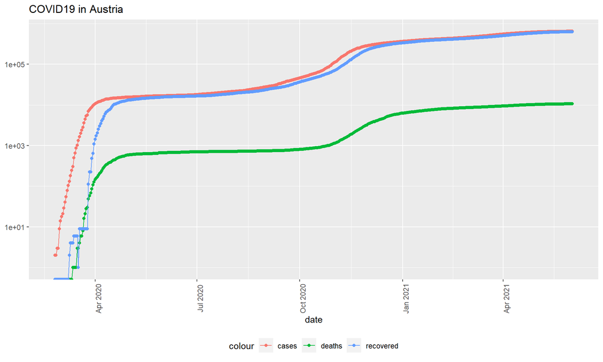

```r
cntry <- "Austria"
eu_covid %>% filter(Country_Region == cntry) %>% filter(cases>0) %>%
  ggplot(aes(x=date, y=cases)) +
  geom_line(aes(color="cases"))+
  geom_point(aes(color="cases"))+
  geom_line(aes(y=deaths, color="deaths"))+
  geom_point(aes(y=deaths, color="deaths"))+
  geom_line(aes(y=recovered, color="recovered"))+
  geom_point(aes(y=recovered, color="recovered"))+
  scale_y_log10()+theme(legend.position="bottom", axis.text.x=element_text(angle=90))+
  labs(title=str_c("COVID19 in ", cntry), y=NULL)
```

### Belgium

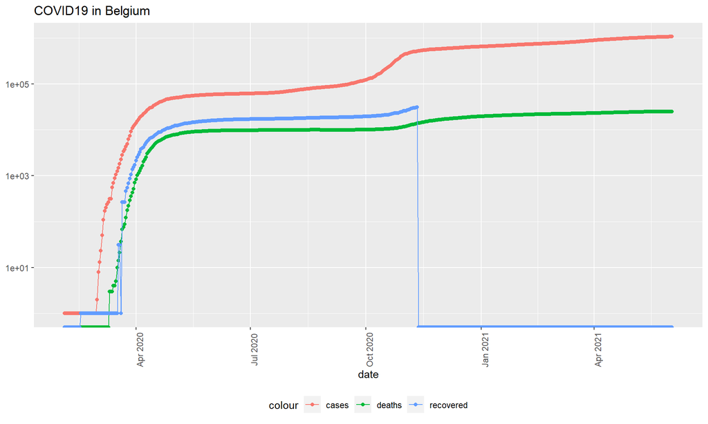

```r
cntry <- "Belgium"
eu_covid %>% filter(Country_Region == cntry) %>% filter(cases>0) %>%
  ggplot(aes(x=date, y=cases)) +
  geom_line(aes(color="cases"))+
  geom_point(aes(color="cases"))+
  geom_line(aes(y=deaths, color="deaths"))+
  geom_point(aes(y=deaths, color="deaths"))+
  geom_line(aes(y=recovered, color="recovered"))+
  geom_point(aes(y=recovered, color="recovered"))+
  scale_y_log10()+theme(legend.position="bottom", axis.text.x=element_text(angle=90))+
  labs(title=str_c("COVID19 in ", cntry), y=NULL)
```

### Cyprus

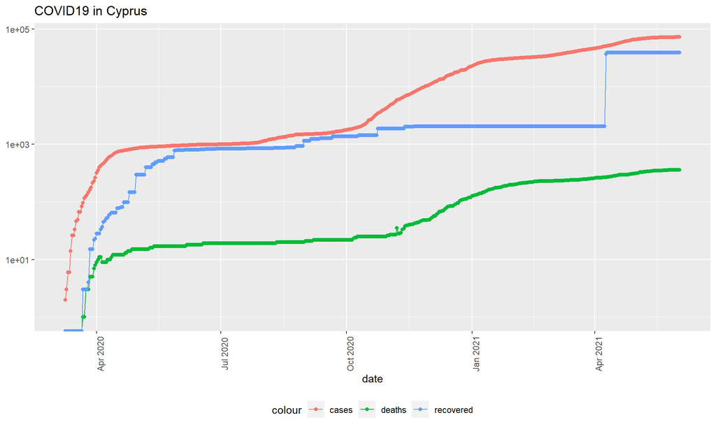

```r
cntry <- "Cyprus"
eu_covid %>% filter(Country_Region == cntry) %>% filter(cases>0) %>%
  ggplot(aes(x=date, y=cases)) +
  geom_line(aes(color="cases"))+
  geom_point(aes(color="cases"))+
  geom_line(aes(y=deaths, color="deaths"))+
  geom_point(aes(y=deaths, color="deaths"))+
  geom_line(aes(y=recovered, color="recovered"))+
  geom_point(aes(y=recovered, color="recovered"))+
  scale_y_log10()+theme(legend.position="bottom", axis.text.x=element_text(angle=90))+
  labs(title=str_c("COVID19 in ", cntry), y=NULL)
```

### Czechia

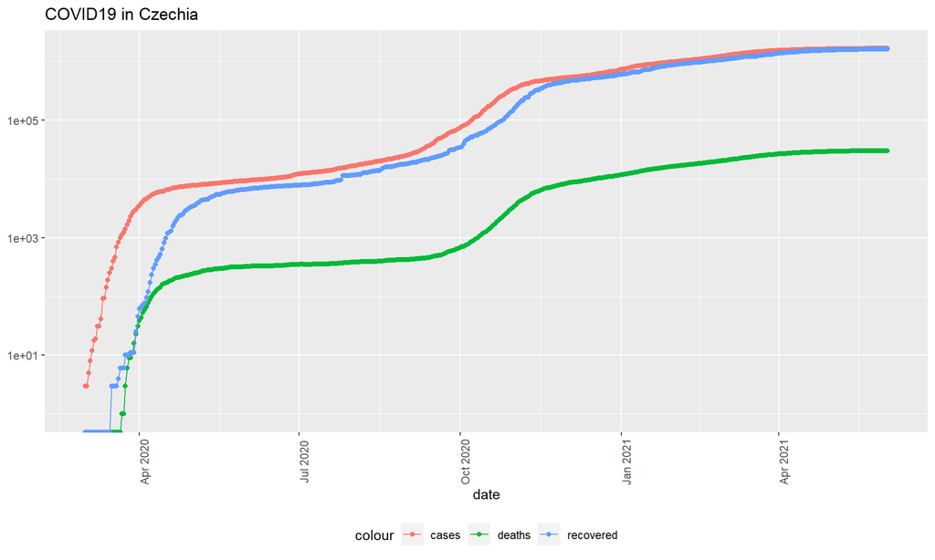

```r
cntry <- "Czechia"
eu_covid %>% filter(Country_Region == cntry) %>% filter(cases>0) %>%
  ggplot(aes(x=date, y=cases)) +
  geom_line(aes(color="cases"))+
  geom_point(aes(color="cases"))+
  geom_line(aes(y=deaths, color="deaths"))+
  geom_point(aes(y=deaths, color="deaths"))+
  geom_line(aes(y=recovered, color="recovered"))+
  geom_point(aes(y=recovered, color="recovered"))+
  scale_y_log10()+theme(legend.position="bottom", axis.text.x=element_text(angle=90))+
  labs(title=str_c("COVID19 in ", cntry), y=NULL)
```

### France

I included territories such as French Guiana within this data, but it would be better to put them in their own graph.

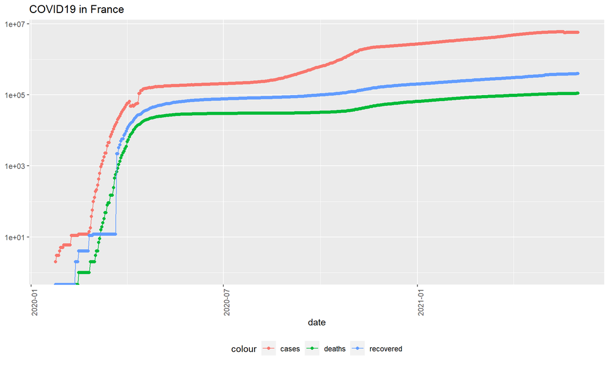

```r
cntry <- "France"
eu_covid %>% filter(Country_Region == cntry) %>% filter(cases>0) %>% group_by("Country_Region", date) %>% summarize(cases = sum(cases), deaths = sum(deaths), recovered = sum(recovered)) %>%
  ggplot(aes(x=date, y=cases)) +
  geom_line(aes(color="cases"))+
  geom_point(aes(color="cases"))+
  geom_line(aes(y=deaths, color="deaths"))+
  geom_point(aes(y=deaths, color="deaths"))+
  geom_line(aes(y=recovered, color="recovered"))+
  geom_point(aes(y=recovered, color="recovered"))+
  scale_y_log10()+theme(legend.position="bottom", axis.text.x=element_text(angle=90))+
  labs(title=str_c("COVID19 in ", cntry), y=NULL)
```

### Greece

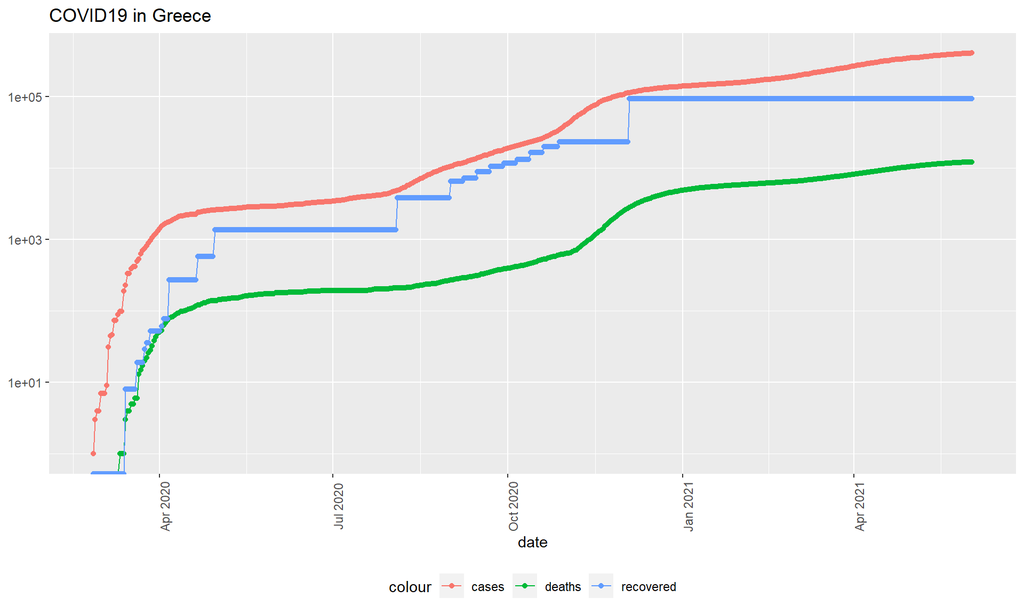

```r
cntry <- "Greece"
eu_covid %>% filter(Country_Region == cntry) %>% filter(cases>0) %>%
  ggplot(aes(x=date, y=cases)) +
  geom_line(aes(color="cases"))+
  geom_point(aes(color="cases"))+
  geom_line(aes(y=deaths, color="deaths"))+
  geom_point(aes(y=deaths, color="deaths"))+
  geom_line(aes(y=recovered, color="recovered"))+
  geom_point(aes(y=recovered, color="recovered"))+
  scale_y_log10()+theme(legend.position="bottom", axis.text.x=element_text(angle=90))+
  labs(title=str_c("COVID19 in ", cntry), y=NULL)
```

### Hungary

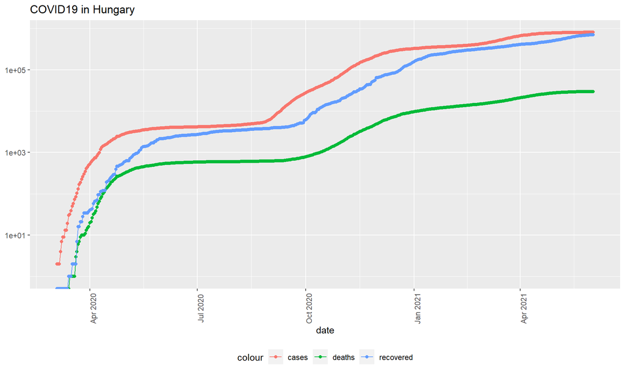

```r
cntry <- "Hungary"
eu_covid %>% filter(Country_Region == cntry) %>% filter(cases>0) %>%
  ggplot(aes(x=date, y=cases)) +
  geom_line(aes(color="cases"))+
  geom_point(aes(color="cases"))+
  geom_line(aes(y=deaths, color="deaths"))+
  geom_point(aes(y=deaths, color="deaths"))+
  geom_line(aes(y=recovered, color="recovered"))+
  geom_point(aes(y=recovered, color="recovered"))+
  scale_y_log10()+theme(legend.position="bottom", axis.text.x=element_text(angle=90))+
  labs(title=str_c("COVID19 in ", cntry), y=NULL)
```

### Ireland

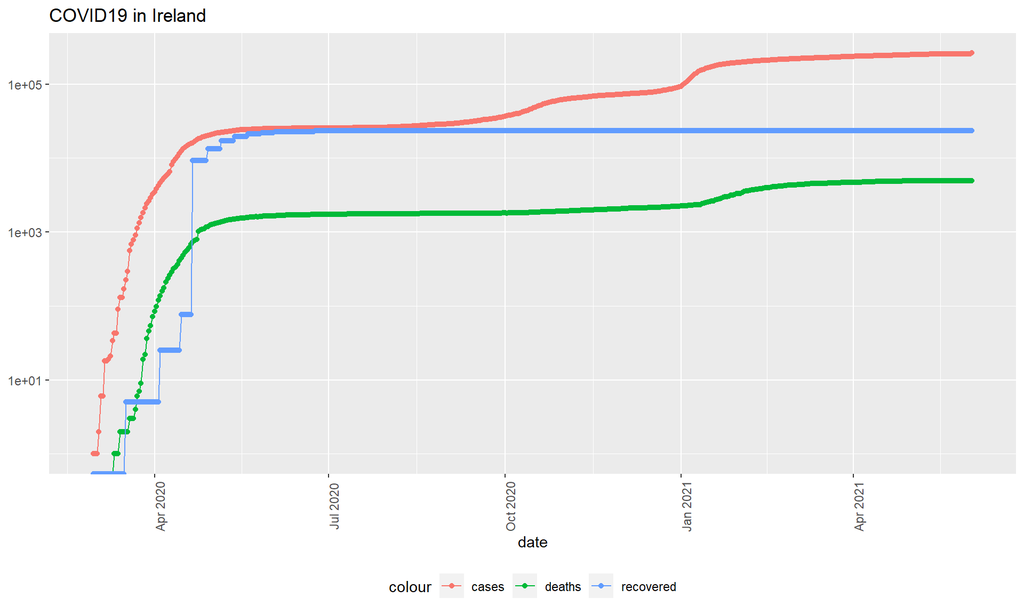

```r
cntry <- "Ireland"
eu_covid %>% filter(Country_Region == cntry) %>% filter(cases>0) %>%
  ggplot(aes(x=date, y=cases)) +
  geom_line(aes(color="cases"))+
  geom_point(aes(color="cases"))+
  geom_line(aes(y=deaths, color="deaths"))+
  geom_point(aes(y=deaths, color="deaths"))+
  geom_line(aes(y=recovered, color="recovered"))+
  geom_point(aes(y=recovered, color="recovered"))+
  scale_y_log10()+theme(legend.position="bottom", axis.text.x=element_text(angle=90))+
  labs(title=str_c("COVID19 in ", cntry), y=NULL)
```

### Italy

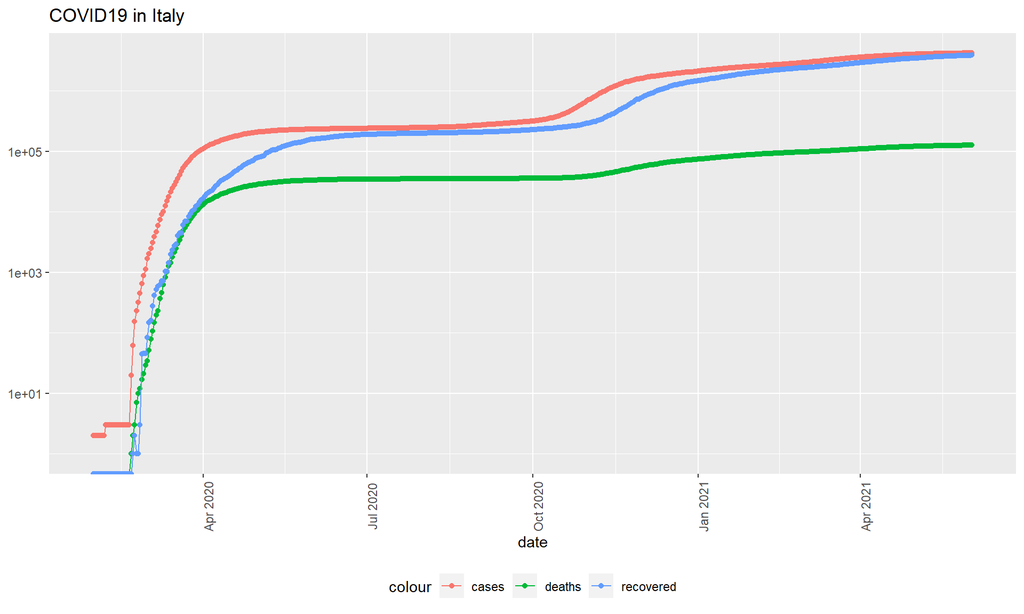

```r
cntry <- "Italy"
eu_covid %>% filter(Country_Region == cntry) %>% filter(cases>0) %>%
  ggplot(aes(x=date, y=cases)) +
  geom_line(aes(color="cases"))+
  geom_point(aes(color="cases"))+
  geom_line(aes(y=deaths, color="deaths"))+
  geom_point(aes(y=deaths, color="deaths"))+
  geom_line(aes(y=recovered, color="recovered"))+
  geom_point(aes(y=recovered, color="recovered"))+
  scale_y_log10()+theme(legend.position="bottom", axis.text.x=element_text(angle=90))+
  labs(title=str_c("COVID19 in ", cntry), y=NULL)
```

### Lithuania

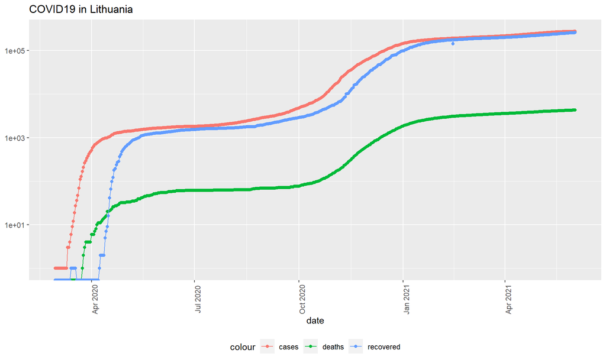

```r
cntry <- "Lithuania"
eu_covid %>% filter(Country_Region == cntry) %>% filter(cases>0) %>%
  ggplot(aes(x=date, y=cases)) +
  geom_line(aes(color="cases"))+
  geom_point(aes(color="cases"))+
  geom_line(aes(y=deaths, color="deaths"))+
  geom_point(aes(y=deaths, color="deaths"))+
  geom_line(aes(y=recovered, color="recovered"))+
  geom_point(aes(y=recovered, color="recovered"))+
  scale_y_log10()+theme(legend.position="bottom", axis.text.x=element_text(angle=90))+
  labs(title=str_c("COVID19 in ", cntry), y=NULL)
```

### Luxembourg

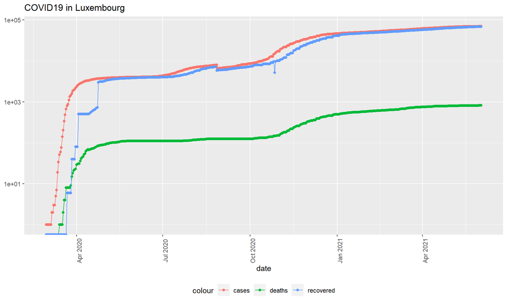

```r
cntry <- "Luxembourg"
eu_covid %>% filter(Country_Region == cntry) %>% filter(cases>0) %>%
  ggplot(aes(x=date, y=cases)) +
  geom_line(aes(color="cases"))+
  geom_point(aes(color="cases"))+
  geom_line(aes(y=deaths, color="deaths"))+
  geom_point(aes(y=deaths, color="deaths"))+
  geom_line(aes(y=recovered, color="recovered"))+
  geom_point(aes(y=recovered, color="recovered"))+
  scale_y_log10()+theme(legend.position="bottom", axis.text.x=element_text(angle=90))+
  labs(title=str_c("COVID19 in ", cntry), y=NULL)
```

### Poland

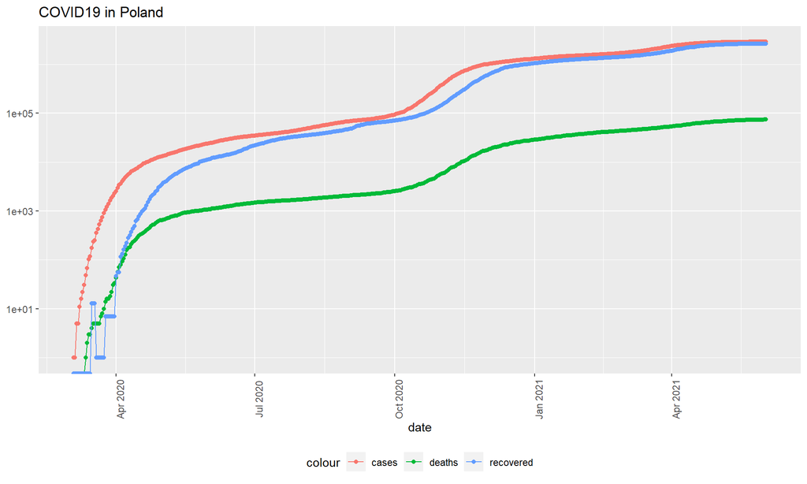

```r
cntry <- "Poland"
eu_covid %>% filter(Country_Region == cntry) %>% filter(cases>0) %>%
  ggplot(aes(x=date, y=cases)) +
  geom_line(aes(color="cases"))+
  geom_point(aes(color="cases"))+
  geom_line(aes(y=deaths, color="deaths"))+
  geom_point(aes(y=deaths, color="deaths"))+
  geom_line(aes(y=recovered, color="recovered"))+
  geom_point(aes(y=recovered, color="recovered"))+
  scale_y_log10()+theme(legend.position="bottom", axis.text.x=element_text(angle=90))+
  labs(title=str_c("COVID19 in ", cntry), y=NULL)
```

### Portugal

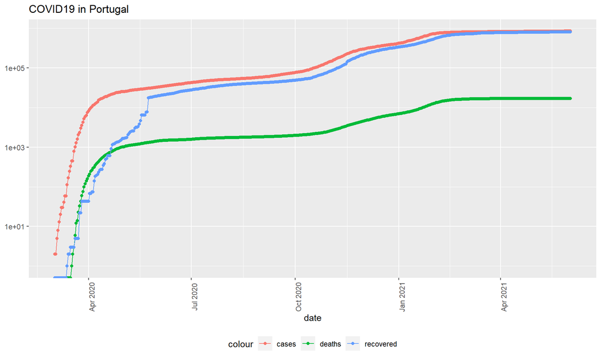

```r
cntry <- "Portugal"
eu_covid %>% filter(Country_Region == cntry) %>% filter(cases>0) %>%
  ggplot(aes(x=date, y=cases)) +
  geom_line(aes(color="cases"))+
  geom_point(aes(color="cases"))+
  geom_line(aes(y=deaths, color="deaths"))+
  geom_point(aes(y=deaths, color="deaths"))+
  geom_line(aes(y=recovered, color="recovered"))+
  geom_point(aes(y=recovered, color="recovered"))+
  scale_y_log10()+theme(legend.position="bottom", axis.text.x=element_text(angle=90))+
  labs(title=str_c("COVID19 in ", cntry), y=NULL)
```

### Slovakia

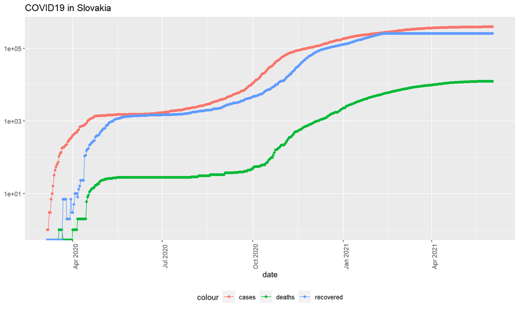

```r
cntry <- "Slovakia"
eu_covid %>% filter(Country_Region == cntry) %>% filter(cases>0) %>%
  ggplot(aes(x=date, y=cases)) +
  geom_line(aes(color="cases"))+
  geom_point(aes(color="cases"))+
  geom_line(aes(y=deaths, color="deaths"))+
  geom_point(aes(y=deaths, color="deaths"))+
  geom_line(aes(y=recovered, color="recovered"))+
  geom_point(aes(y=recovered, color="recovered"))+
  scale_y_log10()+theme(legend.position="bottom", axis.text.x=element_text(angle=90))+
  labs(title=str_c("COVID19 in ", cntry), y=NULL)
```

### Slovenia

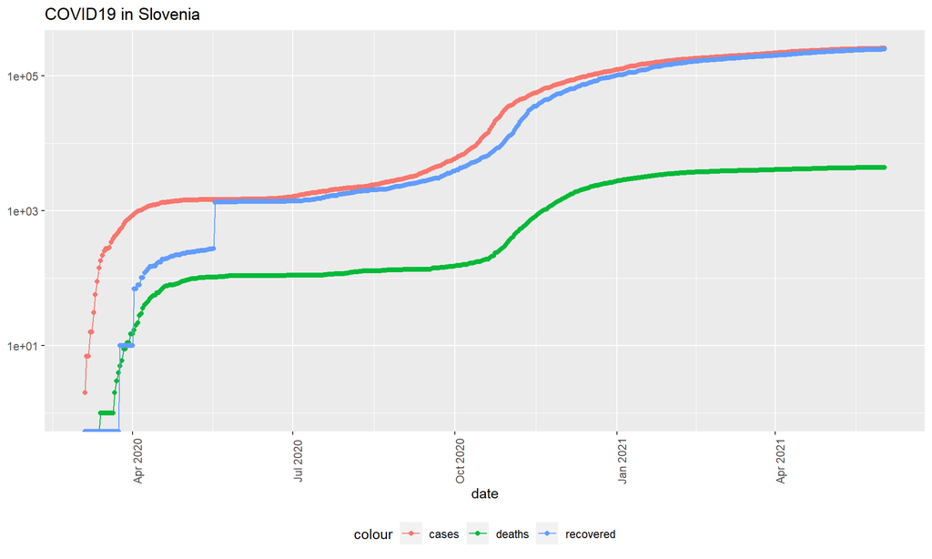

```r
cntry <- "Slovenia"
eu_covid %>% filter(Country_Region == cntry) %>% filter(cases>0) %>%
  ggplot(aes(x=date, y=cases)) +
  geom_line(aes(color="cases"))+
  geom_point(aes(color="cases"))+
  geom_line(aes(y=deaths, color="deaths"))+
  geom_point(aes(y=deaths, color="deaths"))+
  geom_line(aes(y=recovered, color="recovered"))+
  geom_point(aes(y=recovered, color="recovered"))+
  scale_y_log10()+theme(legend.position="bottom", axis.text.x=element_text(angle=90))+
  labs(title=str_c("COVID19 in ", cntry), y=NULL)
```

### Spain

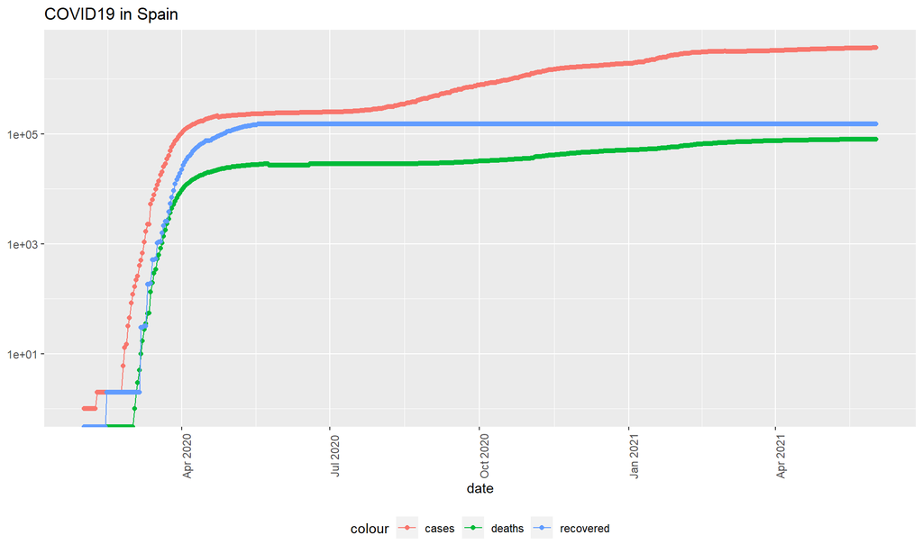

```r
cntry <- "Spain"
eu_covid %>% filter(Country_Region == cntry) %>% filter(cases>0) %>%
  ggplot(aes(x=date, y=cases)) +
  geom_line(aes(color="cases"))+
  geom_point(aes(color="cases"))+
  geom_line(aes(y=deaths, color="deaths"))+
  geom_point(aes(y=deaths, color="deaths"))+
  geom_line(aes(y=recovered, color="recovered"))+
  geom_point(aes(y=recovered, color="recovered"))+
  scale_y_log10()+theme(legend.position="bottom", axis.text.x=element_text(angle=90))+
  labs(title=str_c("COVID19 in ", cntry), y=NULL)
```

### United Kingdom

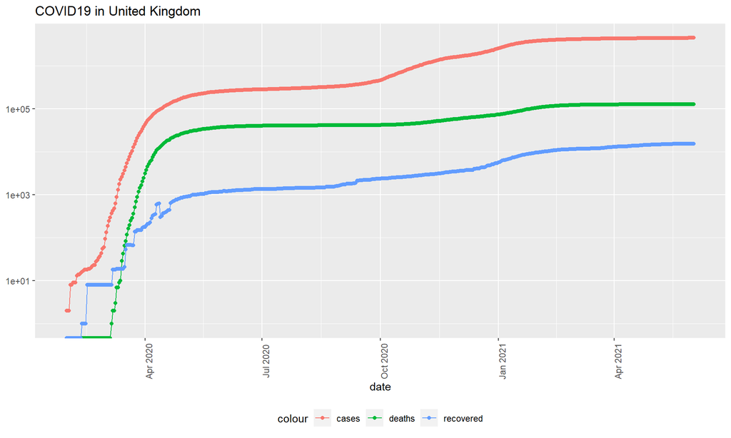

```r
cntry <- "United Kingdom"
eu_covid %>% filter(Country_Region == cntry) %>% filter(cases>0) %>% group_by(Country_Region, date) %>% summarize(recovered = sum(recovered), deaths = sum(deaths), cases=sum(cases)) %>%
  ggplot(aes(x=date, y=cases)) +
  geom_line(aes(color="cases"))+
  geom_point(aes(color="cases"))+
  geom_line(aes(y=deaths, color="deaths"))+
  geom_point(aes(y=deaths, color="deaths"))+
  geom_line(aes(y=recovered, color="recovered"))+
  geom_point(aes(y=recovered, color="recovered"))+
  scale_y_log10()+theme(legend.position="bottom", axis.text.x=element_text(angle=90))+
  labs(title=str_c("COVID19 in ", cntry), y=NULL)
```

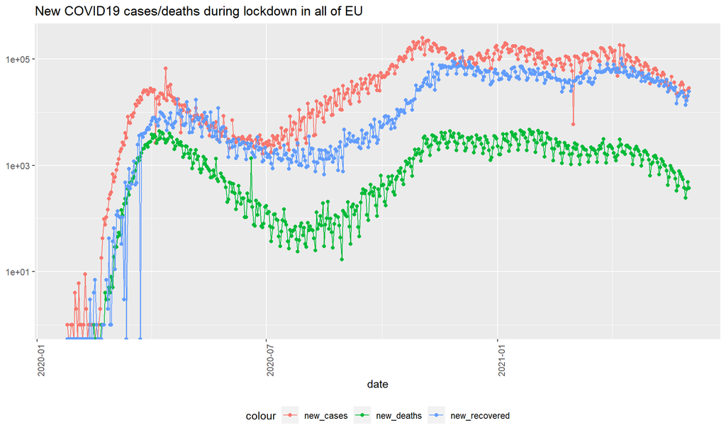

```r
EU_cntries_ttl<- EU_cntries_ttl  %>% mutate(new_recovered = recovered - lag(recovered), new_cases=cases-lag(cases), new_deaths = deaths - lag(deaths))
EU_cntries_ttl %>%
  ggplot(aes(x=date, y=new_cases)) +
  geom_line(aes(color="new_cases"))+
  geom_point(aes(color="new_cases"))+
  geom_line(aes(y=new_deaths, color="new_deaths"))+
  geom_point(aes(y=new_deaths, color="new_deaths"))+
  geom_line(aes(y=new_recovered, color="new_recovered"))+
  geom_point(aes(y=new_recovered, color="new_recovered"))+
  scale_y_log10()+theme(legend.position="bottom", axis.text.x=element_text(angle=90))+
  labs(title=str_c("New COVID19 cases/deaths during lockdown in all of EU"), y=NULL)
```

## Lockdown Visualizations with new cases/deaths

Here we can see the curves the daily change of the cases, deaths and recoveries within individual countries. The graph will only show the data of cases, deaths and recoveries during that countries lockdown. The aim of these lockdowns is to slow down the spread of the virus as to not overwhelm the healthcare system. I will talk about the conclusions of this later in this document.

### Austria

Austria is a clear example of a country that had to go through multiple stay at home orders due to the clear increase of cases and deaths between the two precautionary decisions. But, it shows a fall in cases, deaths, and recoveries.

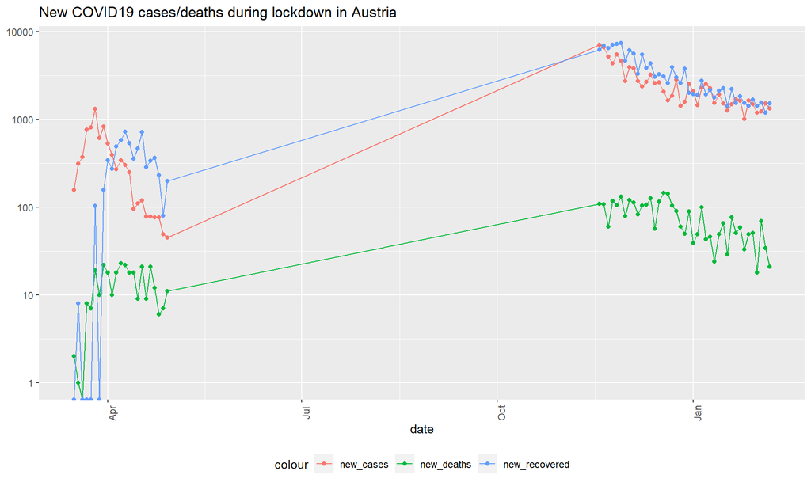

```r
cntry <- "Austria"
lockdown <- eu %>% filter(Country == cntry)
eu_covid %>% filter(Country_Region == cntry) %>% mutate(new_recovered = recovered - lag(recovered), new_cases=cases-lag(cases), new_deaths = deaths - lag(deaths)) %>% filter(date >= lockdown$date_start & date <= lockdown$date_end) %>%
  ggplot(aes(x=date, y=new_cases)) +
  geom_line(aes(color="new_cases"))+
  geom_point(aes(color="new_cases"))+
  geom_line(aes(y=new_deaths, color="new_deaths"))+
  geom_point(aes(y=new_deaths, color="new_deaths"))+
  geom_line(aes(y=new_recovered, color="new_recovered"))+
  geom_point(aes(y=new_recovered, color="new_recovered"))+
  scale_y_log10()+theme(legend.position="bottom", axis.text.x=element_text(angle=90))+
  labs(title=str_c("New COVID19 cases/deaths during lockdown in ", cntry), y=NULL)
```

### Belgium

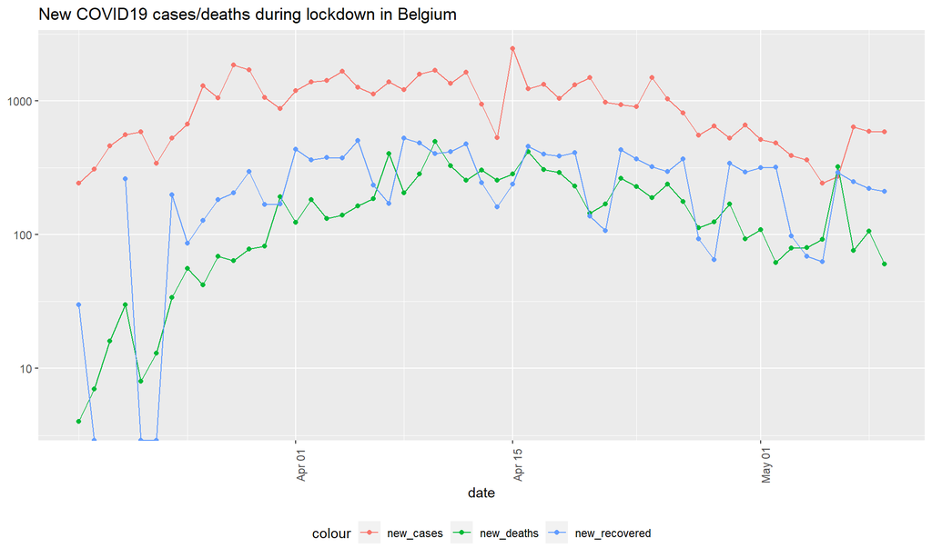

```r
cntry <- "Belgium"
lockdown <- eu %>% filter(Country == cntry)
eu_covid %>% filter(Country_Region == cntry) %>% mutate(new_recovered = recovered - lag(recovered),new_cases=cases-lag(cases), new_deaths = deaths - lag(deaths)) %>% filter(date >= lockdown$date_start & date <= lockdown$date_end) %>%
  ggplot(aes(x=date, y=new_cases)) +
  geom_line(aes(color="new_cases"))+
  geom_point(aes(color="new_cases"))+
  geom_line(aes(y=new_deaths, color="new_deaths"))+
  geom_point(aes(y=new_deaths, color="new_deaths"))+
  geom_line(aes(y=new_recovered, color="new_recovered"))+
  geom_point(aes(y=new_recovered, color="new_recovered"))+
  scale_y_log10()+theme(legend.position="bottom", axis.text.x=element_text(angle=90))+
  labs(title=str_c("New COVID19 cases/deaths during lockdown in ", cntry), y=NULL)
```

### Cyprus

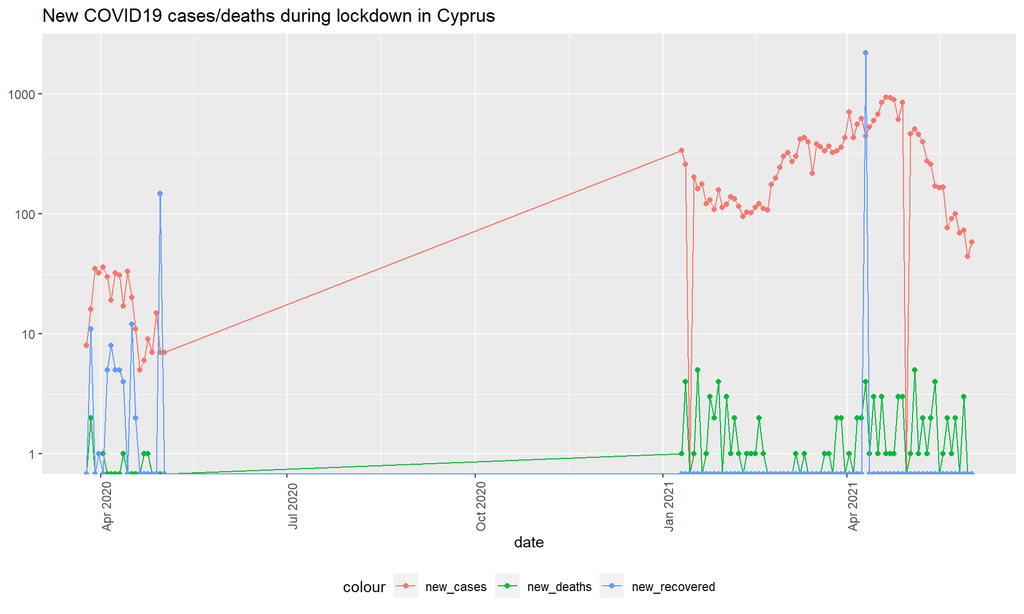

```r
cntry <- "Cyprus"
lockdown <- eu %>% filter(Country == cntry)
eu_covid %>% filter(Country_Region == cntry) %>% mutate(new_recovered = recovered - lag(recovered),new_cases=cases-lag(cases), new_deaths = deaths - lag(deaths)) %>% filter(date >= lockdown$date_start & date <= lockdown$date_end) %>%
  ggplot(aes(x=date, y=new_cases)) +
  geom_line(aes(color="new_cases"))+
  geom_point(aes(color="new_cases"))+
  geom_line(aes(y=new_deaths, color="new_deaths"))+
  geom_point(aes(y=new_deaths, color="new_deaths"))+
  geom_line(aes(y=new_recovered, color="new_recovered"))+
  geom_point(aes(y=new_recovered, color="new_recovered"))+
  scale_y_log10()+theme(legend.position="bottom", axis.text.x=element_text(angle=90))+
  labs(title=str_c("New COVID19 cases/deaths during lockdown in ", cntry), y=NULL)
```

### Czechia

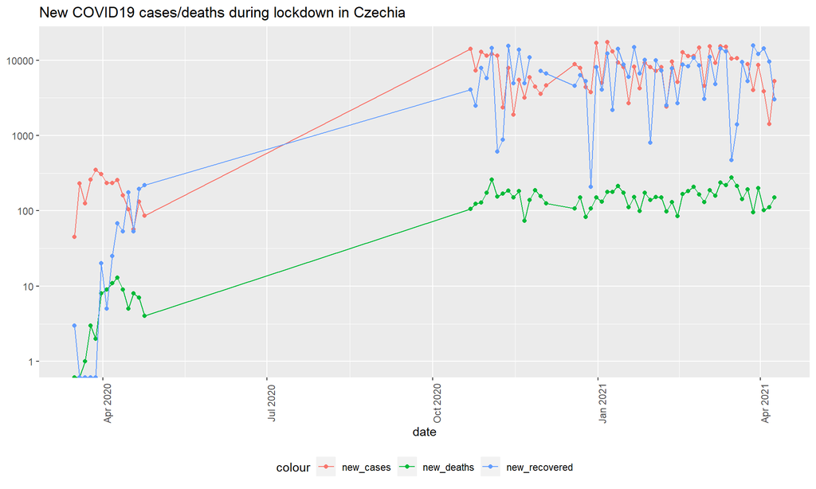

```r
cntry <- "Czechia"
lockdown <- eu %>% filter(Country == cntry)
eu_covid %>% filter(Country_Region == cntry) %>% mutate(new_recovered = recovered - lag(recovered),new_cases=cases-lag(cases), new_deaths = deaths - lag(deaths)) %>% filter(date >= lockdown$date_start & date <= lockdown$date_end) %>%
  ggplot(aes(x=date, y=new_cases)) +
  geom_line(aes(color="new_cases"))+
  geom_point(aes(color="new_cases"))+
  geom_line(aes(y=new_deaths, color="new_deaths"))+
  geom_point(aes(y=new_deaths, color="new_deaths"))+
  geom_line(aes(y=new_recovered, color="new_recovered"))+
  geom_point(aes(y=new_recovered, color="new_recovered"))+
  scale_y_log10()+theme(legend.position="bottom", axis.text.x=element_text(angle=90))+
  labs(title=str_c("New COVID19 cases/deaths during lockdown in ", cntry), y=NULL)
```

### France

I included territories such as French Guiana within this data, but it would be better to put them in their own graph.

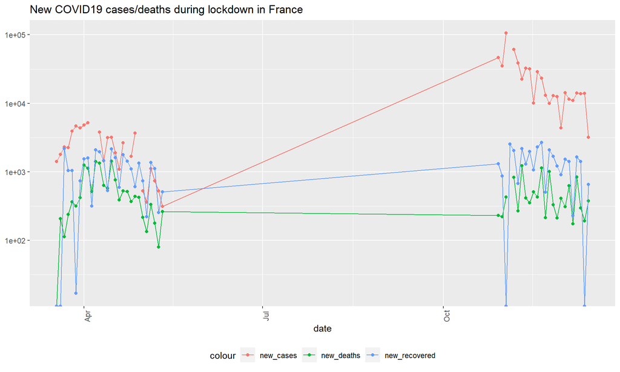

```r
cntry <- "France"
lockdown <- eu %>% filter(Country == cntry)
eu_covid %>% filter(Country_Region == cntry) %>% mutate(new_recovered = recovered - lag(recovered), new_cases=cases-lag(cases), new_deaths = deaths - lag(deaths)) %>% group_by("Country_Region", date) %>% summarize(recovered = sum(recovered), new_recovered = sum(new_recovered), cases = sum(cases), deaths = sum(deaths), new_cases=sum(new_cases), new_deaths=sum(new_deaths)) %>%filter(date >= lockdown$date_start & date <= lockdown$date_end) %>%
  ggplot(aes(x=date, y=new_cases)) +
  geom_line(aes(color="new_cases"))+
  geom_point(aes(color="new_cases"))+
  geom_line(aes(y=new_deaths, color="new_deaths"))+
  geom_point(aes(y=new_deaths, color="new_deaths"))+
  geom_line(aes(y=new_recovered, color="new_recovered"))+
  geom_point(aes(y=new_recovered, color="new_recovered"))+
  scale_y_log10()+theme(legend.position="bottom", axis.text.x=element_text(angle=90))+
  labs(title=str_c("New COVID19 cases/deaths during lockdown in ", cntry), y=NULL)
```

### Greece

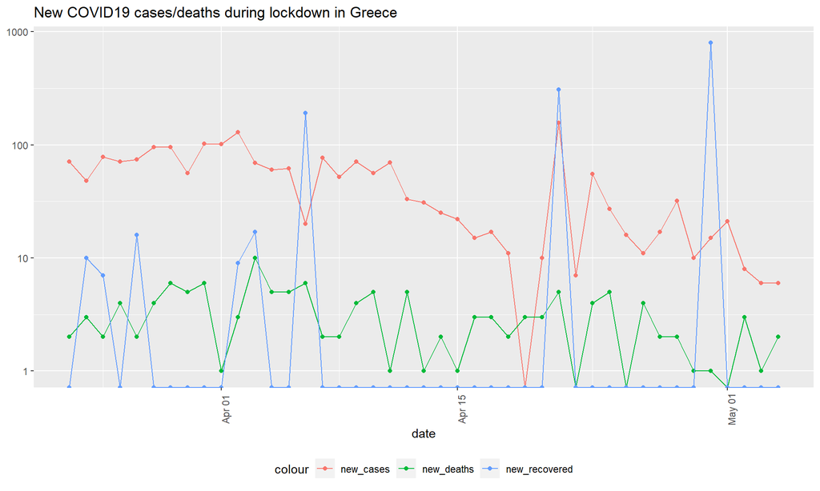

```r
cntry <- "Greece"
lockdown <- eu %>% filter(Country == cntry)
eu_covid %>% filter(Country_Region == cntry) %>% mutate(new_recovered = recovered - lag(recovered),new_cases=cases-lag(cases), new_deaths = deaths - lag(deaths)) %>% filter(date >= lockdown$date_start & date <= lockdown$date_end) %>%
  ggplot(aes(x=date, y=new_cases)) +
  geom_line(aes(color="new_cases"))+
  geom_point(aes(color="new_cases"))+
  geom_line(aes(y=new_deaths, color="new_deaths"))+
  geom_point(aes(y=new_deaths, color="new_deaths"))+
  geom_line(aes(y=new_recovered, color="new_recovered"))+
  geom_point(aes(y=new_recovered, color="new_recovered"))+
  scale_y_log10()+theme(legend.position="bottom", axis.text.x=element_text(angle=90))+
  labs(title=str_c("New COVID19 cases/deaths during lockdown in ", cntry), y=NULL)
```

### Hungary

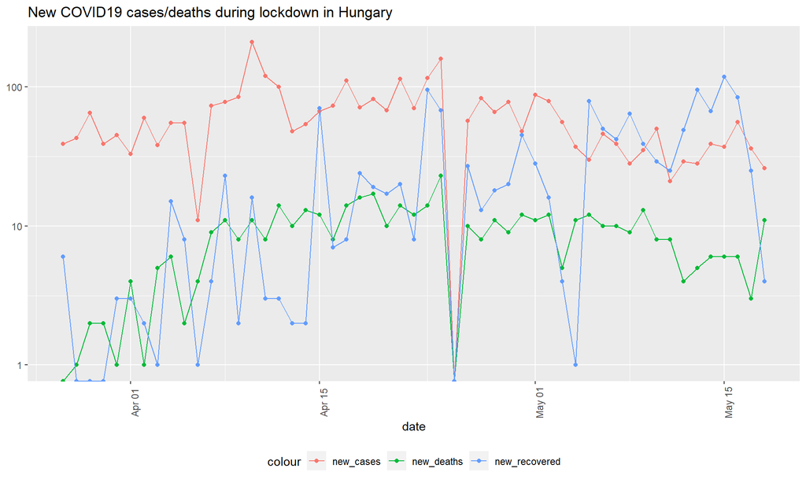

```r
cntry <- "Hungary"
lockdown <- eu %>% filter(Country == cntry)
eu_covid %>% filter(Country_Region == cntry) %>% mutate(new_recovered = recovered - lag(recovered),new_cases=cases-lag(cases), new_deaths = deaths - lag(deaths)) %>% filter(date >= lockdown$date_start & date <= lockdown$date_end) %>%
  ggplot(aes(x=date, y=new_cases)) +
  geom_line(aes(color="new_cases"))+
  geom_point(aes(color="new_cases"))+
  geom_line(aes(y=new_deaths, color="new_deaths"))+
  geom_point(aes(y=new_deaths, color="new_deaths"))+
  geom_line(aes(y=new_recovered, color="new_recovered"))+
  geom_point(aes(y=new_recovered, color="new_recovered"))+
  scale_y_log10()+theme(legend.position="bottom", axis.text.x=element_text(angle=90))+
  labs(title=str_c("New COVID19 cases/deaths during lockdown in ", cntry), y=NULL)
```

### Ireland

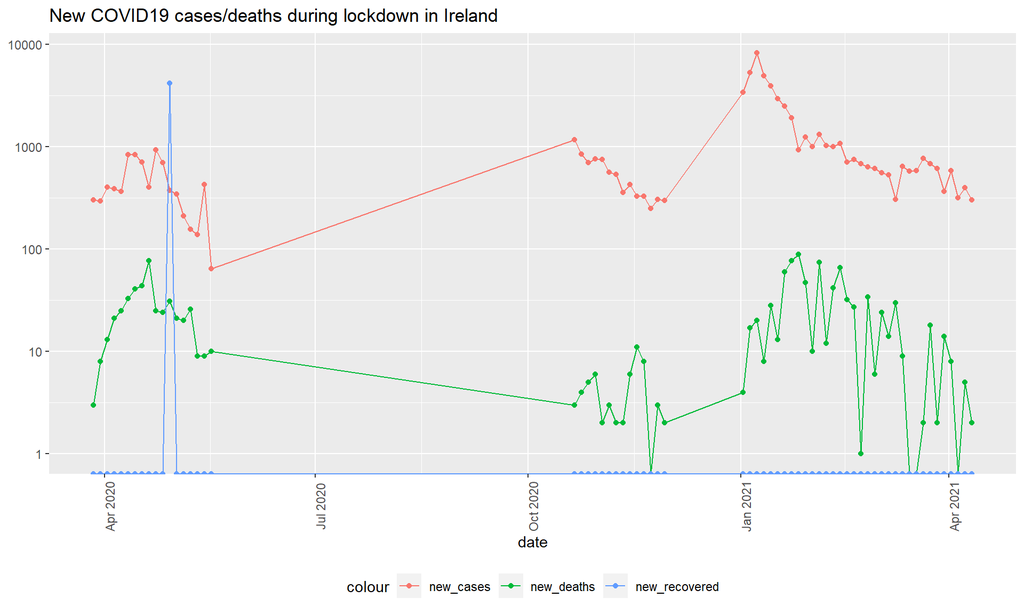

```r
cntry <- "Ireland"
lockdown <- eu %>% filter(Country == cntry)
eu_covid %>% filter(Country_Region == cntry) %>% mutate(new_recovered = recovered - lag(recovered),new_cases=cases-lag(cases), new_deaths = deaths - lag(deaths)) %>% filter(date >= lockdown$date_start & date <= lockdown$date_end) %>%
  ggplot(aes(x=date, y=new_cases)) +
  geom_line(aes(color="new_cases"))+
  geom_point(aes(color="new_cases"))+
  geom_line(aes(y=new_deaths, color="new_deaths"))+
  geom_point(aes(y=new_deaths, color="new_deaths"))+
  geom_line(aes(y=new_recovered, color="new_recovered"))+
  geom_point(aes(y=new_recovered, color="new_recovered"))+
  scale_y_log10()+theme(legend.position="bottom", axis.text.x=element_text(angle=90))+
  labs(title=str_c("New COVID19 cases/deaths during lockdown in ", cntry), y=NULL)
```

### Italy

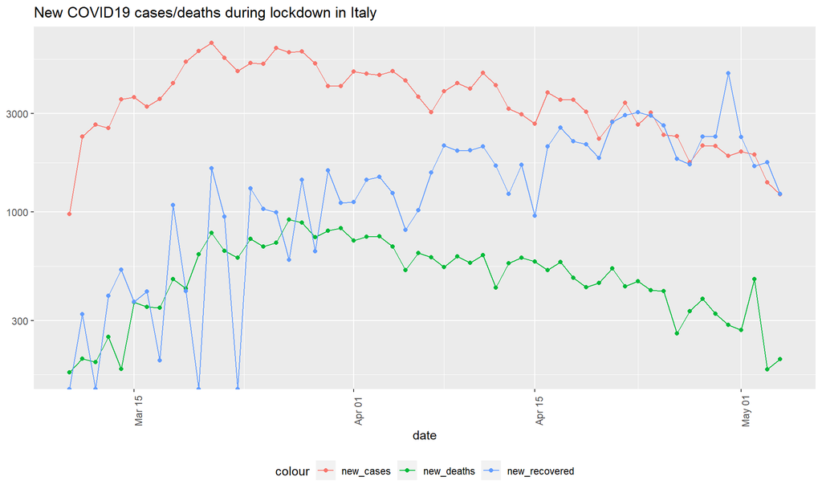

```r
cntry <- "Italy"
lockdown <- eu %>% filter(Country == cntry)
eu_covid %>% filter(Country_Region == cntry) %>% mutate(new_recovered = recovered - lag(recovered),new_cases=cases-lag(cases), new_deaths = deaths - lag(deaths)) %>% filter(date >= lockdown$date_start & date <= lockdown$date_end) %>%
  ggplot(aes(x=date, y=new_cases)) +
  geom_line(aes(color="new_cases"))+
  geom_point(aes(color="new_cases"))+
  geom_line(aes(y=new_deaths, color="new_deaths"))+
  geom_point(aes(y=new_deaths, color="new_deaths"))+
  geom_line(aes(y=new_recovered, color="new_recovered"))+
  geom_point(aes(y=new_recovered, color="new_recovered"))+
  scale_y_log10()+theme(legend.position="bottom", axis.text.x=element_text(angle=90))+
  labs(title=str_c("New COVID19 cases/deaths during lockdown in ", cntry), y=NULL)
```

### Lithuania

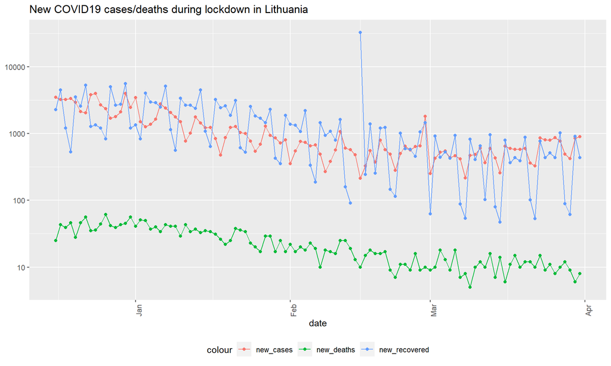

```r
cntry <- "Lithuania"
lockdown <- eu %>% filter(Country == cntry)
eu_covid %>% filter(Country_Region == cntry) %>% mutate(new_recovered = recovered - lag(recovered),new_cases=cases-lag(cases), new_deaths = deaths - lag(deaths)) %>% filter(date >= lockdown$date_start & date <= lockdown$date_end) %>%
  ggplot(aes(x=date, y=new_cases)) +
  geom_line(aes(color="new_cases"))+
  geom_point(aes(color="new_cases"))+
  geom_line(aes(y=new_deaths, color="new_deaths"))+
  geom_point(aes(y=new_deaths, color="new_deaths"))+
  geom_line(aes(y=new_recovered, color="new_recovered"))+
  geom_point(aes(y=new_recovered, color="new_recovered"))+
  scale_y_log10()+theme(legend.position="bottom", axis.text.x=element_text(angle=90))+
  labs(title=str_c("New COVID19 cases/deaths during lockdown in ", cntry), y=NULL)
```

### Luxembourg

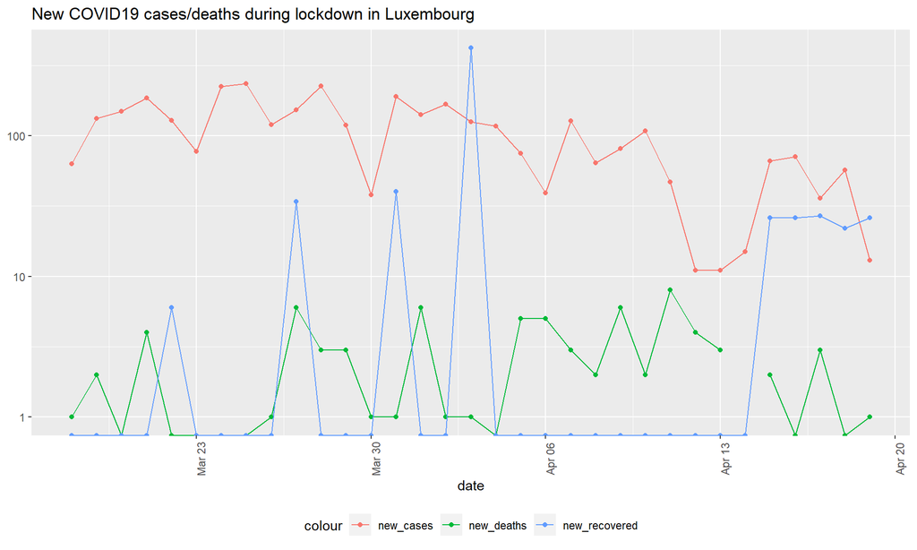

```r
cntry <- "Luxembourg"
lockdown <- eu %>% filter(Country == cntry)
eu_covid %>% filter(Country_Region == cntry) %>% mutate(new_recovered = recovered - lag(recovered),new_cases=cases-lag(cases), new_deaths = deaths - lag(deaths)) %>% filter(date >= lockdown$date_start & date <= lockdown$date_end) %>%
  ggplot(aes(x=date, y=new_cases)) +
  geom_line(aes(color="new_cases"))+
  geom_point(aes(color="new_cases"))+
  geom_line(aes(y=new_deaths, color="new_deaths"))+
  geom_point(aes(y=new_deaths, color="new_deaths"))+
  geom_line(aes(y=new_recovered, color="new_recovered"))+
  geom_point(aes(y=new_recovered, color="new_recovered"))+
  scale_y_log10()+theme(legend.position="bottom", axis.text.x=element_text(angle=90))+
  labs(title=str_c("New COVID19 cases/deaths during lockdown in ", cntry), y=NULL)
```

### Poland

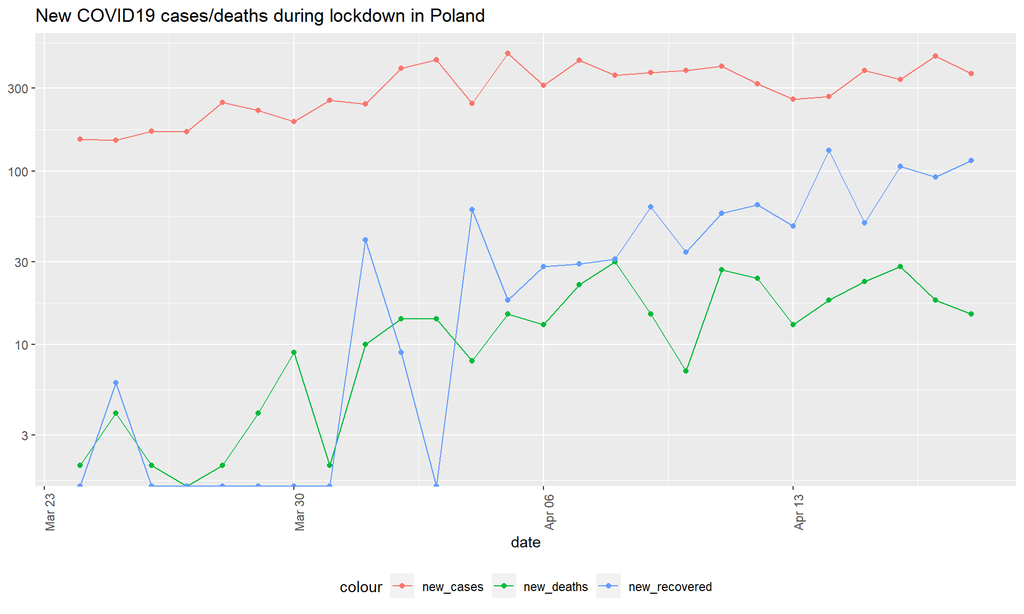

```r
cntry <- "Poland"
lockdown <- eu %>% filter(Country == cntry)
eu_covid %>% filter(Country_Region == cntry) %>% mutate(new_recovered = recovered - lag(recovered),new_cases=cases-lag(cases), new_deaths = deaths - lag(deaths)) %>% filter(date >= lockdown$date_start & date <= lockdown$date_end) %>%
  ggplot(aes(x=date, y=new_cases)) +
  geom_line(aes(color="new_cases"))+
  geom_point(aes(color="new_cases"))+
  geom_line(aes(y=new_deaths, color="new_deaths"))+
  geom_point(aes(y=new_deaths, color="new_deaths"))+
  geom_line(aes(y=new_recovered, color="new_recovered"))+
  geom_point(aes(y=new_recovered, color="new_recovered"))+
  scale_y_log10()+theme(legend.position="bottom", axis.text.x=element_text(angle=90))+
  labs(title=str_c("New COVID19 cases/deaths during lockdown in ", cntry), y=NULL)
```

### Portugal

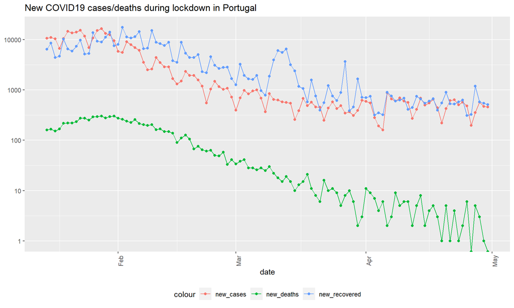

```r
cntry <- "Portugal"
lockdown <- eu %>% filter(Country == cntry)
eu_covid %>% filter(Country_Region == cntry) %>% mutate(new_recovered = recovered - lag(recovered),new_cases=cases-lag(cases), new_deaths = deaths - lag(deaths)) %>% filter(date >= lockdown$date_start & date <= lockdown$date_end) %>%
  ggplot(aes(x=date, y=new_cases)) +
  geom_line(aes(color="new_cases"))+
  geom_point(aes(color="new_cases"))+
  geom_line(aes(y=new_deaths, color="new_deaths"))+
  geom_point(aes(y=new_deaths, color="new_deaths"))+
  geom_line(aes(y=new_recovered, color="new_recovered"))+
  geom_point(aes(y=new_recovered, color="new_recovered"))+
  scale_y_log10()+theme(legend.position="bottom", axis.text.x=element_text(angle=90))+
  labs(title=str_c("New COVID19 cases/deaths during lockdown in ", cntry), y=NULL)
```

### Slovakia

Slovakia stopped reporting new recoveries to the ECDC around Feb 12th of 2021.

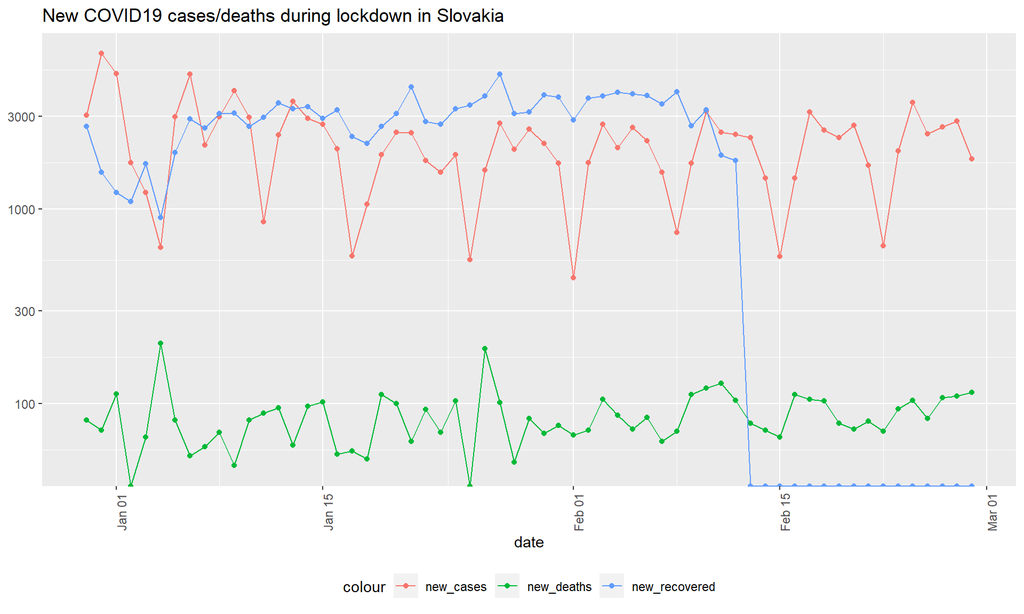

```r
cntry <- "Slovakia"
lockdown <- eu %>% filter(Country == cntry)
eu_covid %>% filter(Country_Region == cntry) %>% mutate(new_recovered = recovered - lag(recovered),new_cases=cases-lag(cases), new_deaths = deaths - lag(deaths)) %>% filter(date >= lockdown$date_start & date <= lockdown$date_end) %>%
  ggplot(aes(x=date, y=new_cases)) +
  geom_line(aes(color="new_cases"))+
  geom_point(aes(color="new_cases"))+
  geom_line(aes(y=new_deaths, color="new_deaths"))+
  geom_point(aes(y=new_deaths, color="new_deaths"))+
  geom_line(aes(y=new_recovered, color="new_recovered"))+
  geom_point(aes(y=new_recovered, color="new_recovered"))+
  scale_y_log10()+theme(legend.position="bottom", axis.text.x=element_text(angle=90))+
  labs(title=str_c("New COVID19 cases/deaths during lockdown in ", cntry), y=NULL)
```

### Slovenia

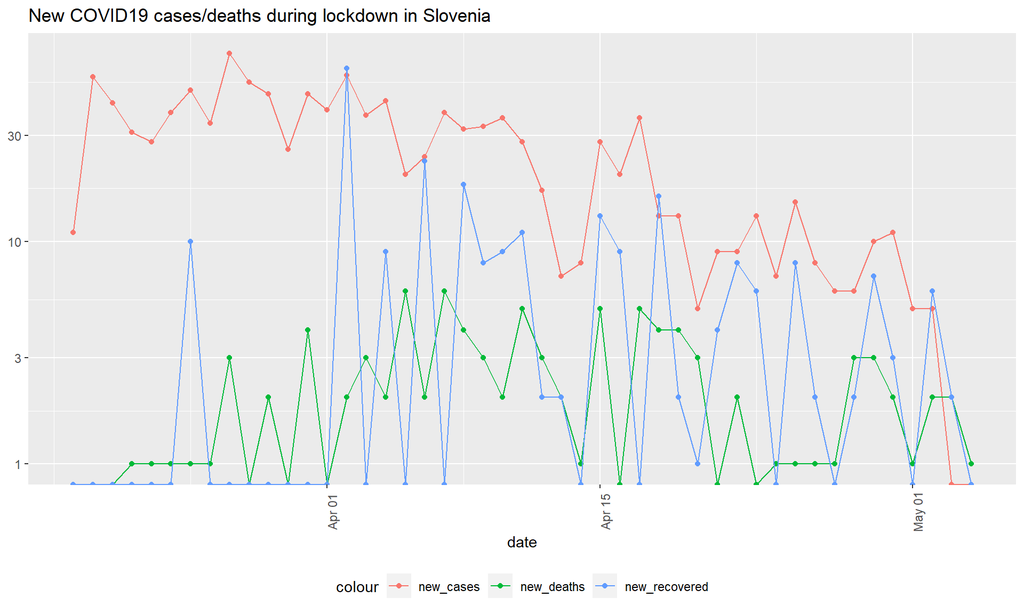

```r
cntry <- "Slovenia"
lockdown <- eu %>% filter(Country == cntry)
eu_covid %>% filter(Country_Region == cntry) %>% mutate(new_recovered = recovered - lag(recovered),new_cases=cases-lag(cases), new_deaths = deaths - lag(deaths)) %>% filter(date >= lockdown$date_start & date <= lockdown$date_end) %>%
  ggplot(aes(x=date, y=new_cases)) +
  geom_line(aes(color="new_cases"))+
  geom_point(aes(color="new_cases"))+
  geom_line(aes(y=new_deaths, color="new_deaths"))+
  geom_point(aes(y=new_deaths, color="new_deaths"))+
  geom_line(aes(y=new_recovered, color="new_recovered"))+
  geom_point(aes(y=new_recovered, color="new_recovered"))+
  scale_y_log10()+theme(legend.position="bottom", axis.text.x=element_text(angle=90))+
  labs(title=str_c("New COVID19 cases/deaths during lockdown in ", cntry), y=NULL)
```

### Spain

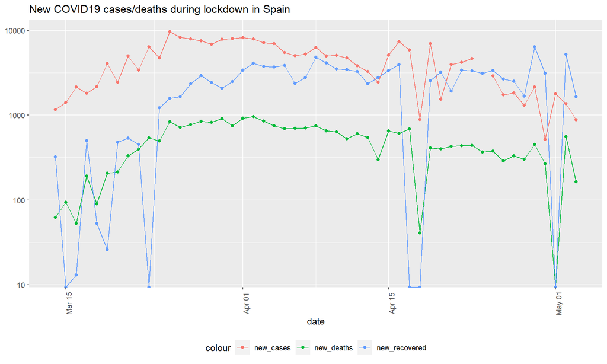

```r
cntry <- "Spain"
lockdown <- eu %>% filter(Country == cntry)
eu_covid %>% filter(Country_Region == cntry) %>% mutate(new_recovered = recovered - lag(recovered),new_cases=cases-lag(cases), new_deaths = deaths - lag(deaths)) %>% filter(date >= lockdown$date_start & date <= lockdown$date_end) %>%
  ggplot(aes(x=date, y=new_cases)) +
  geom_line(aes(color="new_cases"))+
  geom_point(aes(color="new_cases"))+
  geom_line(aes(y=new_deaths, color="new_deaths"))+
  geom_point(aes(y=new_deaths, color="new_deaths"))+
  geom_line(aes(y=new_recovered, color="new_recovered"))+
  geom_point(aes(y=new_recovered, color="new_recovered"))+
  scale_y_log10()+theme(legend.position="bottom", axis.text.x=element_text(angle=90))+
  labs(title=str_c("New COVID19 cases/deaths during lockdown in ", cntry), y=NULL)
```

### United Kingdom

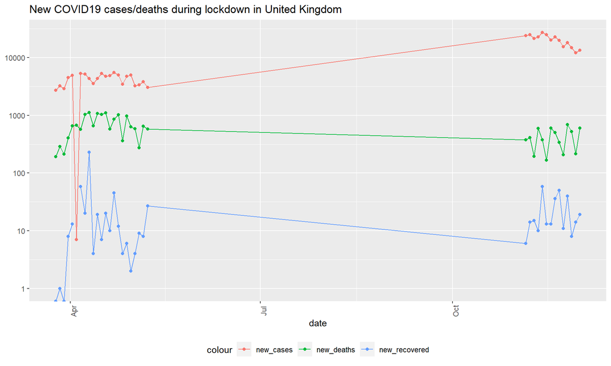

```r
cntry <- "United Kingdom"
lockdown <- eu %>% filter(Country == cntry)
eu_covid %>% filter(Country_Region == cntry) %>% mutate(new_recovered = recovered - lag(recovered), new_cases=cases-lag(cases), new_deaths = deaths - lag(deaths)) %>% group_by(Country_Region, date) %>% summarize(recovered = sum(recovered), deaths = sum(deaths), cases=sum(cases), new_cases=sum(new_cases), new_deaths=sum(new_deaths), new_recovered = sum(new_recovered)) %>% filter(date >= lockdown$date_start & date <= lockdown$date_end) %>%
  ggplot(aes(x=date, y=new_cases)) +
  geom_line(aes(color="new_cases"))+
  geom_point(aes(color="new_cases"))+
  geom_line(aes(y=new_deaths, color="new_deaths"))+
  geom_point(aes(y=new_deaths, color="new_deaths"))+
  geom_line(aes(y=new_recovered, color="new_recovered"))+
  geom_point(aes(y=new_recovered, color="new_recovered"))+
  scale_y_log10()+theme(legend.position="bottom", axis.text.x=element_text(angle=90))+
  labs(title=str_c("New COVID19 cases/deaths during lockdown in ", cntry), y=NULL)
```

Some countries fail to report their daily newly recovered, this might be the fault of many systems that need to be connected or a failure by my code to see that change.

## Modelling

I decided to run the same model we did in class, as I am a beginner within modelling of data. First, we need to calculate the cases/thousand, and deaths/thousand

```r
EUTotal <- eu_covid %>% group_by(Country_Region) %>%
  summarize(deaths = max(deaths),
            cases = max(cases),
            population = max(Population),
            cases_per_thou = 1000*cases/population,
            deaths_per_thou = 1000*deaths/population)
EUTotal
```

```
## # A tibble: 17 x 6
##    Country_Region deaths   cases population cases_per_thou deaths_per_thou
##    <chr>           <dbl>   <dbl>      <dbl>          <dbl>           <dbl>
##  1 Austria         10621  645552    9006400           71.7           1.18
##  2 Belgium         24982 1065358   11589616           91.9           2.16
##  3 Cyprus            361   72573    1207361           60.1           0.299
##  4 Czechia         30126 1662256   10708982          155.            2.81
##  5 France         108834 5863138   65273512           89.8           1.67
##  6 Greece          12145  405542   10423056           38.9           1.17
##  7 Hungary         29774  804987    9660350           83.3           3.08
##  8 Ireland          4941  262787    4937796           53.2           1.00
##  9 Italy          126283 4223200   60461828           69.8           2.09
## 10 Lithuania        4283  275198    2722291          101.            1.57
## 11 Luxembourg        818   70027     625976          112.            1.31
## 12 Poland          73984 2873527   37846605           75.9           1.95
## 13 Portugal        17026  850262   10196707           83.4           1.67
## 14 Slovakia        12366  389990    5459643           71.4           2.26
## 15 Slovenia         4380  254419    2078932          122.            2.11
## 16 Spain           80049 3687762   46754783           78.9           1.71
## 17 United Kingdom 127794 4494699   67886004           66.2           1.88
```

Next, we run the linear model on the data to find the correlation between the cases and deaths

```r
mod <- lm(deaths_per_thou ~ cases_per_thou, data=EUTotal)
summary(mod)
```

```
##
## Call:
## lm(formula = deaths_per_thou ~ cases_per_thou, data = EUTotal)
##
## Residuals:
##      Min       1Q   Median       3Q      Max
## -1.16500 -0.37738 -0.03422  0.29452  1.32830
##
## Coefficients:
##                Estimate Std. Error t value Pr(>|t|)
## (Intercept)    0.713871   0.474626   1.504   0.1533
## cases_per_thou 0.012480   0.005393   2.314   0.0353 *
## ---
## Signif. codes:  0 '***' 0.001 '**' 0.01 '*' 0.05 '.' 0.1 ' ' 1
##
## Residual standard error: 0.5952 on 15 degrees of freedom
## Multiple R-squared:  0.2631, Adjusted R-squared:  0.2139
## F-statistic: 5.355 on 1 and 15 DF,  p-value: 0.03526
```

```r
EUTotal %>% mutate(pred=predict(mod))
```

```
## # A tibble: 17 x 7
##    Country_Region deaths   cases population cases_per_thou deaths_per_thou  pred
##    <chr>           <dbl>   <dbl>      <dbl>          <dbl>           <dbl> <dbl>
##  1 Austria         10621  645552    9006400           71.7           1.18   1.61
##  2 Belgium         24982 1065358   11589616           91.9           2.16   1.86
##  3 Cyprus            361   72573    1207361           60.1           0.299  1.46
##  4 Czechia         30126 1662256   10708982          155.            2.81   2.65
##  5 France         108834 5863138   65273512           89.8           1.67   1.83
##  6 Greece          12145  405542   10423056           38.9           1.17   1.20
##  7 Hungary         29774  804987    9660350           83.3           3.08   1.75
##  8 Ireland          4941  262787    4937796           53.2           1.00   1.38
##  9 Italy          126283 4223200   60461828           69.8           2.09   1.59
## 10 Lithuania        4283  275198    2722291          101.            1.57   1.98
## 11 Luxembourg        818   70027     625976          112.            1.31   2.11
## 12 Poland          73984 2873527   37846605           75.9           1.95   1.66
## 13 Portugal        17026  850262   10196707           83.4           1.67   1.75
## 14 Slovakia        12366  389990    5459643           71.4           2.26   1.61
## 15 Slovenia         4380  254419    2078932          122.            2.11   2.24
## 16 Spain           80049 3687762   46754783           78.9           1.71   1.70
## 17 United Kingdom 127794 4494699   67886004           66.2           1.88   1.54
```

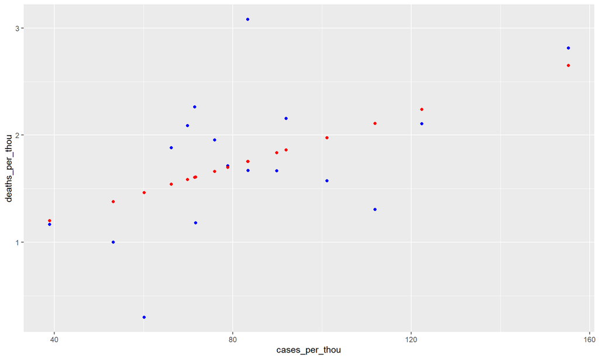

```r
EUTotal_w_pred <- EUTotal %>% mutate(pred=predict(mod))
EUTotal_w_pred %>% ggplot() +
  geom_point(aes(x=cases_per_thou, y = deaths_per_thou), color="blue") +
  geom_point(aes(x=cases_per_thou, y = pred), color="red")
```

## Bias

I believe that the bias comes from the underlying infrastructure of the healthcare systems of each country. This depends highly on reporting of the cases, deaths and recoveries, but not all recoveries are reported, not all cases are reported, and we can have false reporting when it comes to deaths. My personal bias comes when evaluating the countries and removing rows to make my graphs seem more clean.This data does not take into consideration the immunization levels of each country, as that could be releveant to the steady decline of the infection rate. There are many countries that are not on the list that took precautions, and this is may be a bias by the ECDC. But, it removes the study of the effects of Stay at home orders within those countries.